# A comparison of sleep factors and mood levels

## Does more sleep lead to a greater mood level?

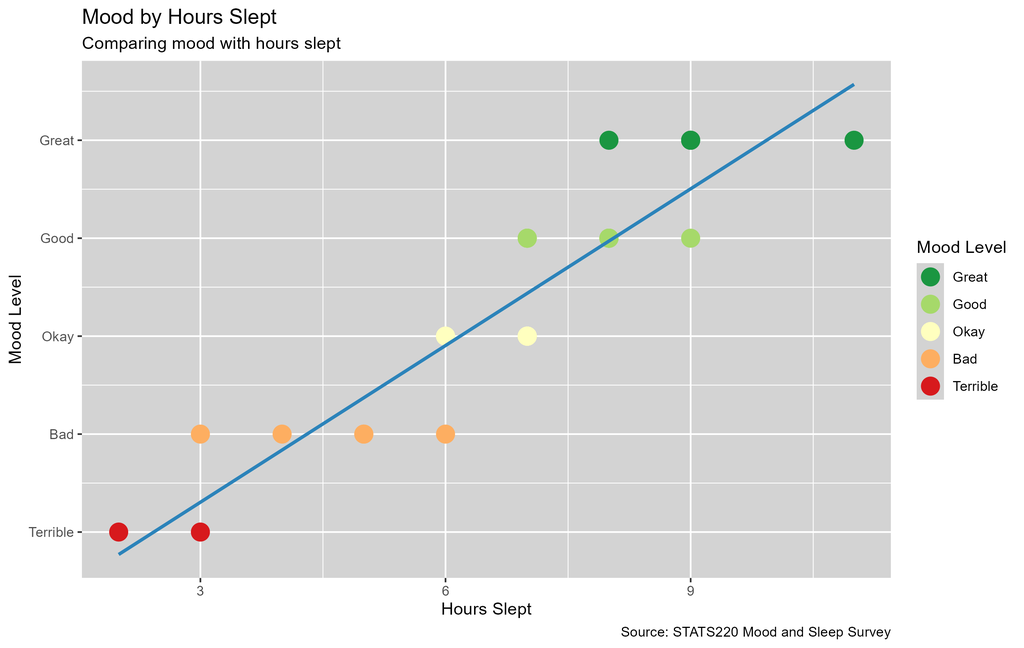

A point graph comparing mood level by hours slept with a linear correlation

This graph is an improved version of the original sleep vs mood graph from Project 2. It highlights how there is a clear positive correlation between sleep time and mood level. This data is better communicated through the use of a scatter plot and a trend line.

## Does more time awake in bed lead to a greater mood level?

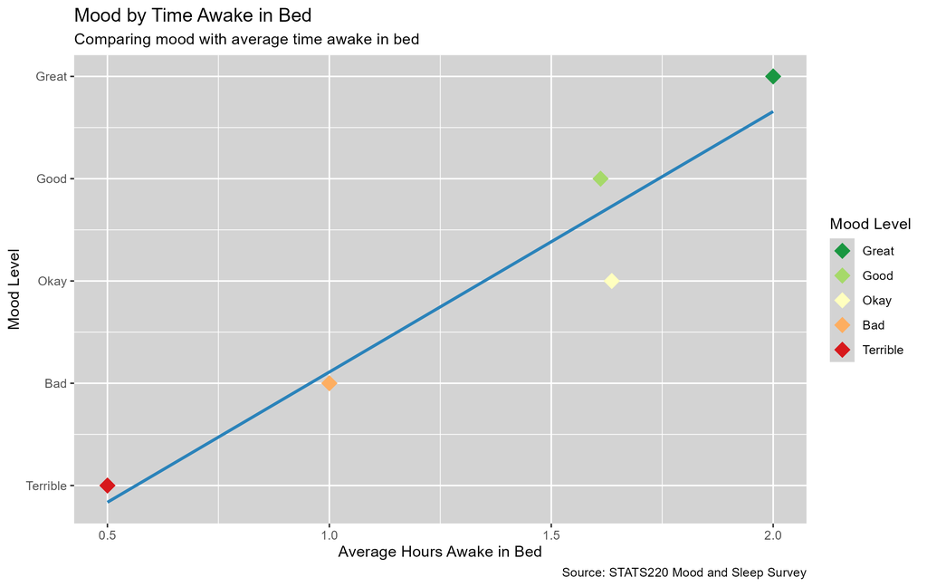

A point graph comparing mood level by hours awake in bed with a linear correlation

It may seem contradictory but this graph illustrates a positive correlation between the time spent awake in bed and an increase in mood level. This goes against logical thinking as more time awake in bed suggests less time asleep. However, the following graph helps to clarify this phenomenon.

## Does more time awake in bed mean more sleep?

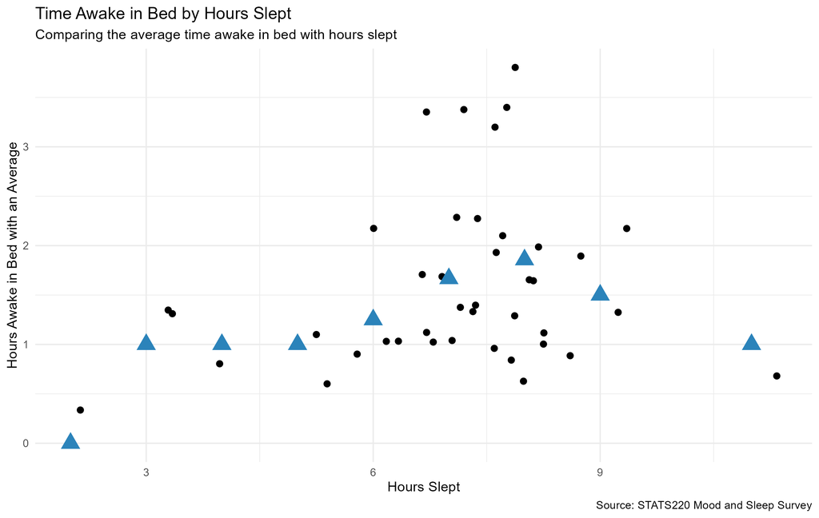

A jitter plot comparing average hours awake in bed by hour slept

The data on this graph supports the previous claim, by showing that, in general, more time awake in bed is followed by longer sleep time. This could be due to a more natural “settle down” period leading to better sleep duration. However, more discussion can be made on whether this was time awake before sleeping or after waking up.

## Do we lose sleep during the school term?

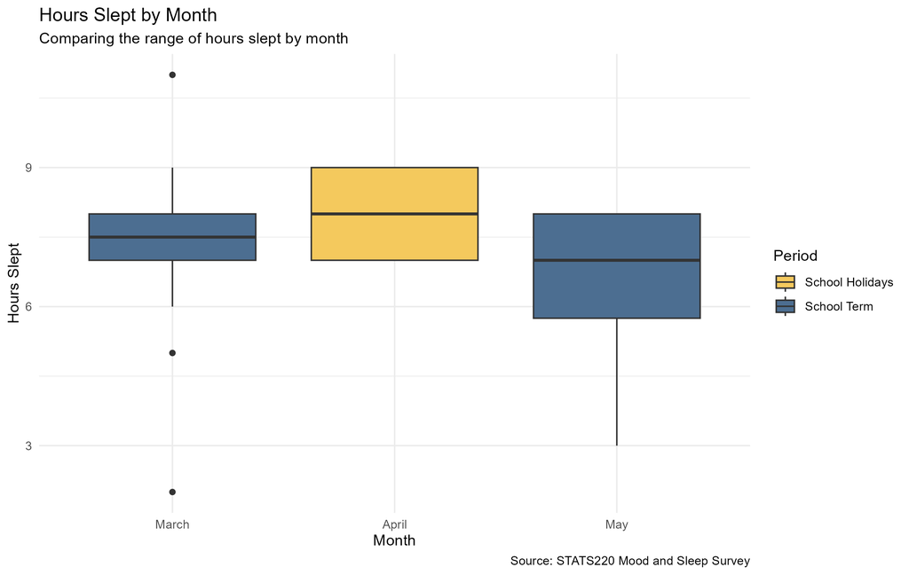

A box plot comparing the range of sleep hours across the months March, April, and May

This was fun graph to emphasize how sleep duration was higher and more consistent during the month of school holidays.This information can be extended by logging sleep data through out the entire year to account for both school semesters and all holidays.

## Dont forget to rest!

[figure not shown]

Sleep time!

Overall, the data collected and summarized from this study aims to highlight the relationship between sleep and mood from the perspective of a university student. It also dives into the factors that influence sleep, such as time awake in bed, and whether it was a school semester or a holiday. I hope that the information provided in this study helps to emphasize not only the importance of sleep but how data technologies can help improve even the most integral parts of our lives.